# Data Visualization: `ggplot` part 1

2021-02-04

## Learning Goals

*At the end of this exercise, you will be able to:*  
1. Understand and apply the syntax of building plots using `ggplot2`.  
2. Build a boxplot using `ggplot2`.  
3. Build a scatterplot using `ggplot2`.  
4. Build a barplot using `ggplot2` and show the difference between `stat=count` and `stat=identity`.

## Where have we been, and where are we going?

At this point you should feel comfortable working in RStudio and using `dplyr` and `tidyr.` You also know how to produce statistical summaries of data and deal with NA’s. It is OK if you need to go back through the labs and find bits of code that work for you, but try and force yourself to originate new chunks.

##Resources - [ggplot2 cheatsheet](https://www.rstudio.com/wp-content/uploads/2015/03/ggplot2-cheatsheet.pdf)

## Libraries

```r
library(tidyverse)
library(naniar)
library(janitor)
library(here)
```

## Grammar of Graphics

The ability to quickly produce and edit graphs and charts is a strength of R. These data visualizations are produced by the package `ggplot2` and it is a core part of the tidyverse. The syntax for using ggplot is specific and common to all of the plots. This is what Hadley Wickham calls a [Grammar of Graphics](http://vita.had.co.nz/papers/layered-grammar.pdf). The “gg” in `ggplot` stands for grammar of graphics.

## Philosophy

What makes a good chart? In my opinion a good chart is elegant in its simplicity. It provides a clean, clear visual of the data without being overwhelming to the reader. This can be hard to do and takes some careful thinking. Always keep in mind that the reader will almost never know the data as well as you do so you need to be mindful about presenting the facts.

## Data Types

We first need to define some of the data types we will use to build plots.

- `discrete` quantitative data that only contains integers
- `continuous` quantitative data that can take any numerical value
- `categorical` qualitative data that can take on a limited number of values

## Basics

The syntax used by ggplot takes some practice to get used to, especially for customizing plots, but the basic elements are the same. It is helpful to think of plots as being built up in layers.

In short, **plot= data + geom_ + aesthetics**.

We start by calling the ggplot function, identifying the data, and specifying the axes. We then add the `geom` type to describe how we want our data represented. Each `geom_` works with specific types of data and R is capable of building plots of single variables, multiple variables, and even maps and 3D plots. Lastly, we add aesthetics.

## Example

To make things easy, let’s start with some built in data.

```r
?iris
names(iris)
```

```
## [1] "Sepal.Length" "Sepal.Width"  "Petal.Length" "Petal.Width"  "Species"
```

```r
glimpse(iris)
```

```
## Rows: 150
## Columns: 5
## $ Sepal.Length <dbl> 5.1, 4.9, 4.7, 4.6, 5.0, 5.4, 4.6, 5.0, 4.4, 4.9, 5.4, 4…
## $ Sepal.Width  <dbl> 3.5, 3.0, 3.2, 3.1, 3.6, 3.9, 3.4, 3.4, 2.9, 3.1, 3.7, 3…
## $ Petal.Length <dbl> 1.4, 1.4, 1.3, 1.5, 1.4, 1.7, 1.4, 1.5, 1.4, 1.5, 1.5, 1…
## $ Petal.Width  <dbl> 0.2, 0.2, 0.2, 0.2, 0.2, 0.4, 0.3, 0.2, 0.2, 0.1, 0.2, 0…
## $ Species      <fct> setosa, setosa, setosa, setosa, setosa, setosa, setosa, …
```

To make a plot, we need to first specify the data and map the aesthetics. The aesthetics include how each variable in our data set will be used. In the example below, I am using the aes() function to identify the x and y variables in the plot.

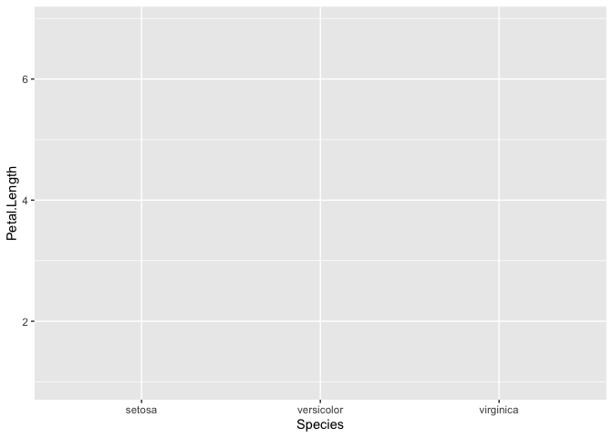

```r
ggplot(data=iris, mapping=aes(x=Species, y=Petal.Length))
```

```r
#Data is iris
#Function called mapping. aes, x axis is species, y axis is petal length
```

-You end up with a blank plot, but things are already where they need to be! You have a ranged of petal length, etc. You’re just missing the kind of plot you want to make, which is the geom type.

Notice that we have a nice background, labeled axes, and even a value range of our variables on the y-axis- but no plot. This is because we need to tell ggplot how we want our data represented. This is called the geometry or `geom()`. There are many types of `geom`, see the ggplot [cheatsheet](https://www.rstudio.com/wp-content/uploads/2015/03/ggplot2-cheatsheet.pdf).

Here we specify that we want a boxplot, indicated by `geom_boxplot()`.

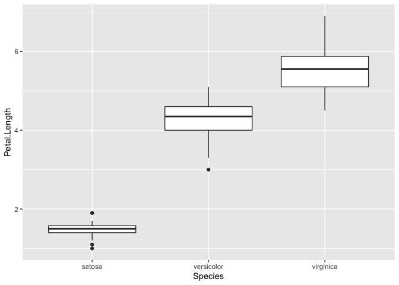

```r
ggplot(data=iris, mapping=aes(x=Species, y=Petal.Length))+geom_boxplot()
```

## Practice

1. Use the iris data to build a scatterplot that compares sepal length vs. sepal width. Use the cheat sheet or help to find the correct `geom_` for a scatterplot.

```r
names(iris)
```

```
## [1] "Sepal.Length" "Sepal.Width"  "Petal.Length" "Petal.Width"  "Species"
```

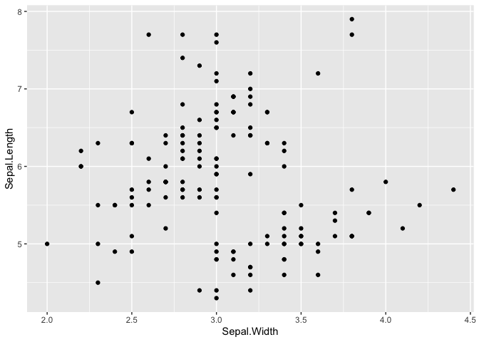

```r
ggplot(data=iris, mapping=aes(x= Sepal.Width, y=Sepal.Length, ))+
  geom_point()
```

```r
#You can switch X and Y axis by respecifying x and y values
```

## Scatterplots and barplots

Now that we have a general idea of the syntax, let’s start by working with two standard plots: 1) scatter plots and 2) bar plots.

## Data

**Database of vertebrate home range sizes.**  
Reference: Tamburello N, Cote IM, Dulvy NK (2015) Energy and the scaling of animal space use. The American Naturalist 186(2):196-211. http://dx.doi.org/10.1086/682070.  
Data: http://datadryad.org/resource/doi:10.5061/dryad.q5j65/1

```r
homerange <- read_csv(here("lab9", "data", "Tamburelloetal_HomeRangeDatabase.csv"))
#Notice the here function
```

## Practice

1. What is the structure of the `homerange` data? Does it have any NA’s? Is it tidy? Do a quick exploratory analysis of your choice below.

```r
glimpse(homerange)
```

```
## Rows: 569
## Columns: 24
## $ taxon                      <chr> "lake fishes", "river fishes", "river fish…
## $ common.name                <chr> "american eel", "blacktail redhorse", "cen…
## $ class                      <chr> "actinopterygii", "actinopterygii", "actin…
## $ order                      <chr> "anguilliformes", "cypriniformes", "cyprin…
## $ family                     <chr> "anguillidae", "catostomidae", "cyprinidae…
## $ genus                      <chr> "anguilla", "moxostoma", "campostoma", "cl…
## $ species                    <chr> "rostrata", "poecilura", "anomalum", "fund…
## $ primarymethod              <chr> "telemetry", "mark-recapture", "mark-recap…
## $ N                          <chr> "16", NA, "20", "26", "17", "5", "2", "2",…
## $ mean.mass.g                <dbl> 887.00, 562.00, 34.00, 4.00, 4.00, 3525.00…
## $ log10.mass                 <dbl> 2.9479236, 2.7497363, 1.5314789, 0.6020600…
## $ alternative.mass.reference <chr> NA, NA, NA, NA, NA, NA, NA, NA, NA, NA, NA…
## $ mean.hra.m2                <dbl> 282750.00, 282.10, 116.11, 125.50, 87.10, …
## $ log10.hra                  <dbl> 5.4514026, 2.4504031, 2.0648696, 2.0986437…
## $ hra.reference              <chr> "Minns, C. K. 1995. Allometry of home rang…
## $ realm                      <chr> "aquatic", "aquatic", "aquatic", "aquatic"…
## $ thermoregulation           <chr> "ectotherm", "ectotherm", "ectotherm", "ec…
## $ locomotion                 <chr> "swimming", "swimming", "swimming", "swimm…
## $ trophic.guild              <chr> "carnivore", "carnivore", "carnivore", "ca…
## $ dimension                  <chr> "3D", "2D", "2D", "2D", "2D", "2D", "2D", …
## $ preymass                   <dbl> NA, NA, NA, NA, NA, NA, 1.39, NA, NA, NA, …
## $ log10.preymass             <dbl> NA, NA, NA, NA, NA, NA, 0.1430148, NA, NA,…
## $ PPMR                       <dbl> NA, NA, NA, NA, NA, NA, 530, NA, NA, NA, N…
## $ prey.size.reference        <chr> NA, NA, NA, NA, NA, NA, "Brose U, et al. 2…
```

```r
naniar::miss_var_summary(homerange)
```

```
## # A tibble: 24 x 3
##    variable                   n_miss pct_miss
##    <chr>                       <int>    <dbl>
##  1 alternative.mass.reference    561   98.6
##  2 preymass                      502   88.2
##  3 log10.preymass                502   88.2
##  4 PPMR                          502   88.2
##  5 prey.size.reference           502   88.2
##  6 N                             375   65.9
##  7 primarymethod                   1    0.176
##  8 taxon                           0    0
##  9 common.name                     0    0
## 10 class                           0    0
## # … with 14 more rows
```

```r
#Shows proportion of missing data
#Know how NAs are represented and where they are concentrated
```

### 1. Scatter Plots

Scatter plots are good at revealing relationships that are not readily visible in the raw data. For now, we will not add regression lines or calculate any r<sup>2</sup> values.

In the case below, we are exploring whether or not there is a relationship between animal mass and home range. We are using the **log transformed values** because there is a large difference in mass and home range among the different species in the data.

```r
names(homerange)
```

```
##  [1] "taxon"                      "common.name"
##  [3] "class"                      "order"
##  [5] "family"                     "genus"
##  [7] "species"                    "primarymethod"
##  [9] "N"                          "mean.mass.g"
## [11] "log10.mass"                 "alternative.mass.reference"
## [13] "mean.hra.m2"                "log10.hra"
## [15] "hra.reference"              "realm"
## [17] "thermoregulation"           "locomotion"
## [19] "trophic.guild"              "dimension"
## [21] "preymass"                   "log10.preymass"
## [23] "PPMR"                       "prey.size.reference"
```

-log10.mass is because there’s a lot of animals in the data, and the range gets so different (ex. mouse vs. elephant) that log function is used

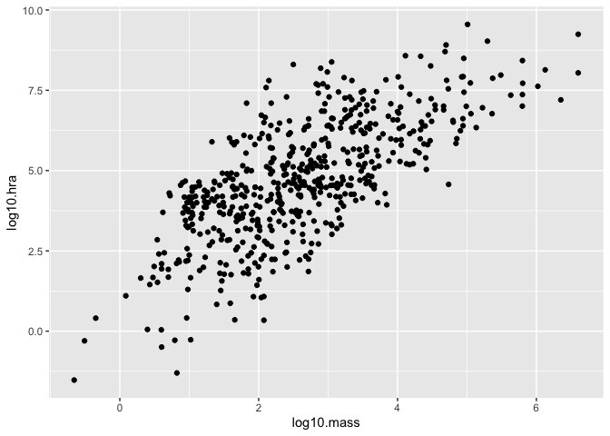

```r
ggplot(data = homerange, mapping = aes(x = log10.mass, y = log10.hra)) + geom_point() #Notice it's a +, not a %>%
```

-This shows the bigger you are, the larger your homerange. Positive trend/correlation!

In big data sets with lots of overlapping values, over-plotting can be an issue. `geom_jitter()` is similar to `geom_point()` but it helps with over plotting by adding some random noise to the data and separating some of the individual points.

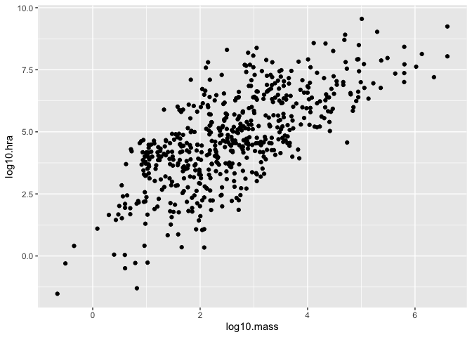

```r
ggplot(data = homerange, mapping = aes(x = log10.mass, y = log10.hra)) +
  geom_jitter()
```

-Somewhat minor difference in this example, but this can be useful for other data!

To add a regression (best of fit) line, we just add another layer.

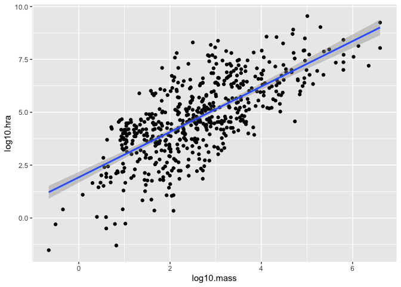

```r
ggplot(data=homerange, mapping=aes(x=log10.mass, y=log10.hra)) +
  geom_point()+
  geom_smooth(method=lm, se=T) #adds the regression line, `se=TRUE` will add standard error
```

```r
#Geom smooth is adding another layer
#Smoothing is a smoothing function
#SE is standard regression error
```

### Practice

1. What is the relationship between log10.hra and log10.preymass? What do you notice about how ggplot treats NA’s?

```r
names(homerange)
```

```
##  [1] "taxon"                      "common.name"
##  [3] "class"                      "order"
##  [5] "family"                     "genus"
##  [7] "species"                    "primarymethod"
##  [9] "N"                          "mean.mass.g"
## [11] "log10.mass"                 "alternative.mass.reference"
## [13] "mean.hra.m2"                "log10.hra"
## [15] "hra.reference"              "realm"
## [17] "thermoregulation"           "locomotion"
## [19] "trophic.guild"              "dimension"
## [21] "preymass"                   "log10.preymass"
## [23] "PPMR"                       "prey.size.reference"
```

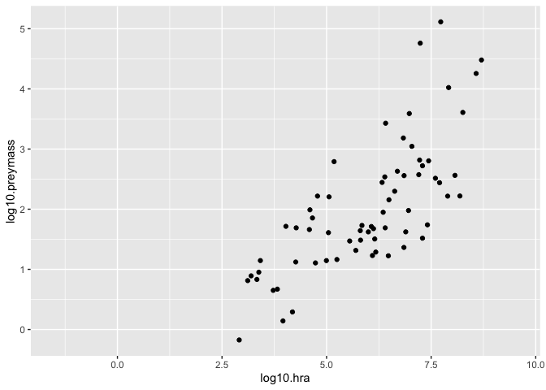

```r
ggplot(data=homerange, mapping=aes(x=log10.hra, y=log10.preymass))+geom_point(na.rm=T)
```

```r
#You can leave data= out, as it will read as the same thing, it's just to make what the command is doing clearer
#Same thing with mapping=
```

-SHOULD be an alert where it says there are 502 rows that contain missing (geom_point). It shows up if na.rm=T wasn’t inserted

### Bar Plot: `geom_bar()`

The simplest type of bar plot counts the number of observations in a categorical variable. In this case, we want to know how many observations are present in the variable `trophic.guild`. Notice that we do not specify a y-axis because it is count by default.

-Only counts the number of times it sees a certain category in a categorical variable. You would not use this with a continuous variable

```r
names(homerange)
```

```
##  [1] "taxon"                      "common.name"
##  [3] "class"                      "order"
##  [5] "family"                     "genus"
##  [7] "species"                    "primarymethod"
##  [9] "N"                          "mean.mass.g"
## [11] "log10.mass"                 "alternative.mass.reference"
## [13] "mean.hra.m2"                "log10.hra"
## [15] "hra.reference"              "realm"
## [17] "thermoregulation"           "locomotion"
## [19] "trophic.guild"              "dimension"
## [21] "preymass"                   "log10.preymass"
## [23] "PPMR"                       "prey.size.reference"
```

```r
homerange %>%
  count(trophic.guild)
```

```
## # A tibble: 2 x 2
##   trophic.guild     n
## * <chr>         <int>
## 1 carnivore       342
## 2 herbivore       227
```

Also notice that we can use pipes! The `mapping=` function is implied by `aes` and so is often left out.

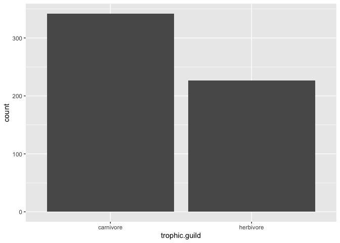

```r
homerange %>%
  ggplot(aes(x=trophic.guild)) + #Don't need to call the data again, don't have to do data=, rather go straight to aes
  geom_bar()
```

```r
#Common error is that you put a pipe rather than a +. This is so common, the error will tell you!
```

-A good practice is to always provide the table with the graph. Make the analysis of the data clear to the reader

### Bar Plot: `geom_col()`

Unlike `geom_bar()`, `geom_col()` allows us to specify an x-axis and a y-axis.

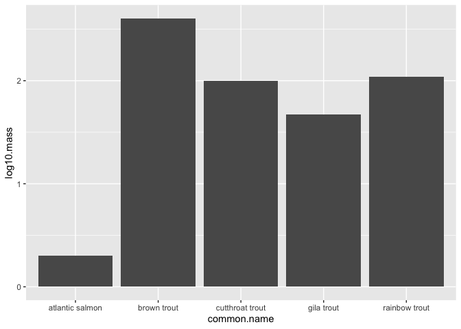

```r
homerange %>%
  filter(family=="salmonidae") %>%
  ggplot(aes(x=common.name, y=log10.mass))+ #Common name of members of salmonidae, then log mass on y axis
  geom_col() #Not geom_bar() in this case. The next example shows you how you can if you want to though!
```

`geom_bar()` with `stat="identity"` `stat="identity"` allows us to map a variable to the y-axis so that we aren’t restricted to counts.

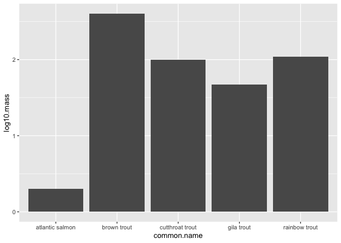

```r
homerange %>%
  filter(family=="salmonidae") %>%
  ggplot(aes(x=common.name, y=log10.mass))+
  geom_bar(stat="identity")
```

-Important that you use geom_bar for counts, and geom_col for specifying an x and y axis

```r
homerange %>%
  group_by(class) %>%
  summarize(mean_body_wt=mean(log10.mass)) #This gives you mean body weight of log10.mass of classes in data
```

```
## # A tibble: 4 x 2
##   class          mean_body_wt
## * <chr>                 <dbl>
## 1 actinopterygii         2.00
## 2 aves                   1.99
## 3 mammalia               3.25
## 4 reptilia               2.53
```

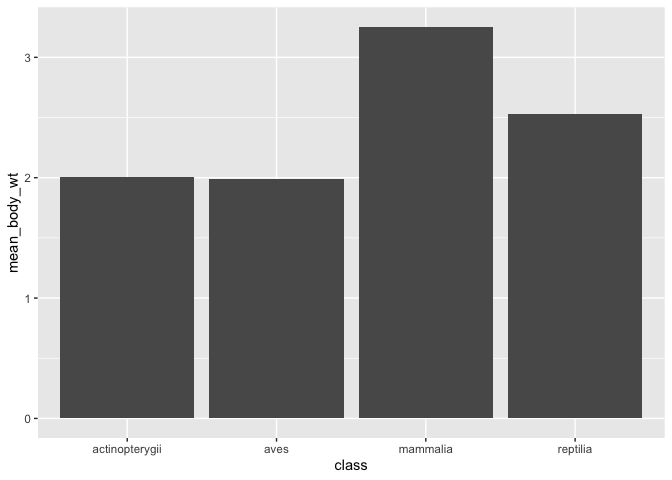

```r
homerange %>%
  group_by(class) %>%
  summarize(mean_body_wt=mean(log10.mass)) %>%
  ggplot(aes(x=class, y=mean_body_wt))+
  geom_col()
```

## Practice

1. Filter the `homerange` data to include `mammals` only.

```r
names(homerange)
```

```
##  [1] "taxon"                      "common.name"
##  [3] "class"                      "order"
##  [5] "family"                     "genus"
##  [7] "species"                    "primarymethod"
##  [9] "N"                          "mean.mass.g"
## [11] "log10.mass"                 "alternative.mass.reference"
## [13] "mean.hra.m2"                "log10.hra"
## [15] "hra.reference"              "realm"
## [17] "thermoregulation"           "locomotion"
## [19] "trophic.guild"              "dimension"
## [21] "preymass"                   "log10.preymass"
## [23] "PPMR"                       "prey.size.reference"
```

```r
glimpse(homerange)
```

```
## Rows: 569
## Columns: 24
## $ taxon                      <chr> "lake fishes", "river fishes", "river fish…
## $ common.name                <chr> "american eel", "blacktail redhorse", "cen…
## $ class                      <chr> "actinopterygii", "actinopterygii", "actin…
## $ order                      <chr> "anguilliformes", "cypriniformes", "cyprin…
## $ family                     <chr> "anguillidae", "catostomidae", "cyprinidae…
## $ genus                      <chr> "anguilla", "moxostoma", "campostoma", "cl…
## $ species                    <chr> "rostrata", "poecilura", "anomalum", "fund…
## $ primarymethod              <chr> "telemetry", "mark-recapture", "mark-recap…
## $ N                          <chr> "16", NA, "20", "26", "17", "5", "2", "2",…
## $ mean.mass.g                <dbl> 887.00, 562.00, 34.00, 4.00, 4.00, 3525.00…
## $ log10.mass                 <dbl> 2.9479236, 2.7497363, 1.5314789, 0.6020600…
## $ alternative.mass.reference <chr> NA, NA, NA, NA, NA, NA, NA, NA, NA, NA, NA…
## $ mean.hra.m2                <dbl> 282750.00, 282.10, 116.11, 125.50, 87.10, …
## $ log10.hra                  <dbl> 5.4514026, 2.4504031, 2.0648696, 2.0986437…
## $ hra.reference              <chr> "Minns, C. K. 1995. Allometry of home rang…
## $ realm                      <chr> "aquatic", "aquatic", "aquatic", "aquatic"…
## $ thermoregulation           <chr> "ectotherm", "ectotherm", "ectotherm", "ec…
## $ locomotion                 <chr> "swimming", "swimming", "swimming", "swimm…
## $ trophic.guild              <chr> "carnivore", "carnivore", "carnivore", "ca…
## $ dimension                  <chr> "3D", "2D", "2D", "2D", "2D", "2D", "2D", …
## $ preymass                   <dbl> NA, NA, NA, NA, NA, NA, 1.39, NA, NA, NA, …
## $ log10.preymass             <dbl> NA, NA, NA, NA, NA, NA, 0.1430148, NA, NA,…
## $ PPMR                       <dbl> NA, NA, NA, NA, NA, NA, 530, NA, NA, NA, N…
## $ prey.size.reference        <chr> NA, NA, NA, NA, NA, NA, "Brose U, et al. 2…
```

```r
homerange %>%
  filter(class=="mammalia")
```

```
## # A tibble: 238 x 24
##    taxon common.name class order family genus species primarymethod N
##    <chr> <chr>       <chr> <chr> <chr>  <chr> <chr>   <chr>         <chr>
##  1 mamm… giant gold… mamm… afro… chrys… chry… trevel… telemetry*    <NA>
##  2 mamm… Grant's go… mamm… afro… chrys… erem… granti  telemetry*    <NA>
##  3 mamm… pronghorn   mamm… arti… antil… anti… americ… telemetry*    <NA>
##  4 mamm… impala      mamm… arti… bovid… aepy… melamp… telemetry*    <NA>
##  5 mamm… hartebeest  mamm… arti… bovid… alce… busela… telemetry*    <NA>
##  6 mamm… barbary sh… mamm… arti… bovid… ammo… lervia  telemetry*    <NA>
##  7 mamm… American b… mamm… arti… bovid… bison bison   telemetry*    <NA>
##  8 mamm… European b… mamm… arti… bovid… bison bonasus telemetry*    <NA>
##  9 mamm… goat        mamm… arti… bovid… capra hircus  telemetry*    <NA>
## 10 mamm… Spanish ib… mamm… arti… bovid… capra pyrena… telemetry*    <NA>
## # … with 228 more rows, and 15 more variables: mean.mass.g <dbl>,
## #   log10.mass <dbl>, alternative.mass.reference <chr>, mean.hra.m2 <dbl>,
## #   log10.hra <dbl>, hra.reference <chr>, realm <chr>, thermoregulation <chr>,
## #   locomotion <chr>, trophic.guild <chr>, dimension <chr>, preymass <dbl>,
## #   log10.preymass <dbl>, PPMR <dbl>, prey.size.reference <chr>
```

-If you ever get lost, you can use summary functions like names(homerange) or glimpse(homerange) to remember what is called what!

2. Are there more herbivores or carnivores in mammals? Make a bar plot that shows their relative numbers.

```r
homerange %>%
  filter(class=="mammalia") %>%
  group_by(trophic.guild) %>%
  count()
```

```
## # A tibble: 2 x 2
## # Groups:   trophic.guild [2]
##   trophic.guild     n
##   <chr>         <int>
## 1 carnivore        80
## 2 herbivore       158
```

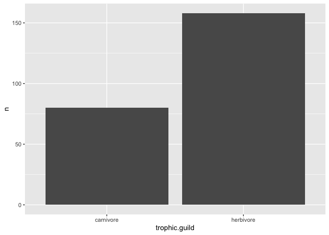

```r
homerange %>%
  filter(class=="mammalia") %>%
  group_by(trophic.guild) %>%
  count() %>%
  ggplot(aes(x=trophic.guild, y=n))+
  geom_col()
```

-If x and y are flipped, it just flips graph, which can be helpful depending on how you want things arranged

3. Make a bar plot that shows the masses of the top 10 smallest mammals.

```r
names(homerange)
```

```
##  [1] "taxon"                      "common.name"
##  [3] "class"                      "order"
##  [5] "family"                     "genus"
##  [7] "species"                    "primarymethod"
##  [9] "N"                          "mean.mass.g"
## [11] "log10.mass"                 "alternative.mass.reference"
## [13] "mean.hra.m2"                "log10.hra"
## [15] "hra.reference"              "realm"
## [17] "thermoregulation"           "locomotion"
## [19] "trophic.guild"              "dimension"
## [21] "preymass"                   "log10.preymass"
## [23] "PPMR"                       "prey.size.reference"
```

```r
homerange %>%
  filter(class=="mammalia") %>%
  top_n(-10, log10.mass) #top_n, you want in this case bottom 10 (-) of log10.mass
```

```
## # A tibble: 10 x 24
##    taxon common.name class order family genus species primarymethod N
##    <chr> <chr>       <chr> <chr> <chr>  <chr> <chr>   <chr>         <chr>
##  1 mamm… Northern t… mamm… dide… didel… mono… americ… telemetry*    <NA>
##  2 mamm… southern g… mamm… roden crice… onyc… torrid… telemetry*    <NA>
##  3 mamm… salt marsh… mamm… rode… crice… reit… ravive… telemetry*    <NA>
##  4 mamm… wood mouse  mamm… rode… murid… apod… sylvat… telemetry*    <NA>
##  5 mamm… greater wh… mamm… sori… soric… croc… russula telemetry*    <NA>
##  6 mamm… arctic shr… mamm… sori… soric… sorex arctic… telemetry*    <NA>
##  7 mamm… cinereus s… mamm… sori… soric… sorex cinere… telemetry*    <NA>
##  8 mamm… crowned sh… mamm… sori… soric… sorex corona… telemetry*    <NA>
##  9 mamm… slender sh… mamm… sori… soric… sorex gracil… telemetry*    <NA>
## 10 mamm… long-clawe… mamm… sori… soric… sorex unguic… telemetry*    <NA>
## # … with 15 more variables: mean.mass.g <dbl>, log10.mass <dbl>,
## #   alternative.mass.reference <chr>, mean.hra.m2 <dbl>, log10.hra <dbl>,
## #   hra.reference <chr>, realm <chr>, thermoregulation <chr>, locomotion <chr>,
## #   trophic.guild <chr>, dimension <chr>, preymass <dbl>, log10.preymass <dbl>,
## #   PPMR <dbl>, prey.size.reference <chr>
```

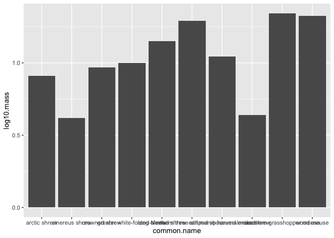

```r
homerange %>%
  filter(class=="mammalia") %>%
  top_n(-10, log10.mass) %>%
  ggplot(aes(x=common.name, y=log10.mass))+
  geom_col() #Since you want to add 2 variables specified, needs to be geom_col
```

-Some of this looks messy, so what can you do? Do below!

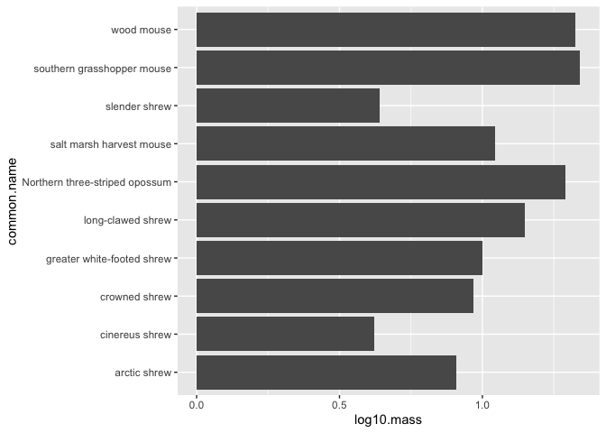

```r
homerange %>%
  filter(class=="mammalia") %>%
  top_n(-10, log10.mass) %>%
  ggplot(aes(x=common.name, y=log10.mass))+
  geom_col()+
  coord_flip() #Coordinates flip: flips X and Y axis
```

-Nice if you can see data in an orderly way, so do this by adding in x=reorder -x=reorder, common name reordered by log10.mass

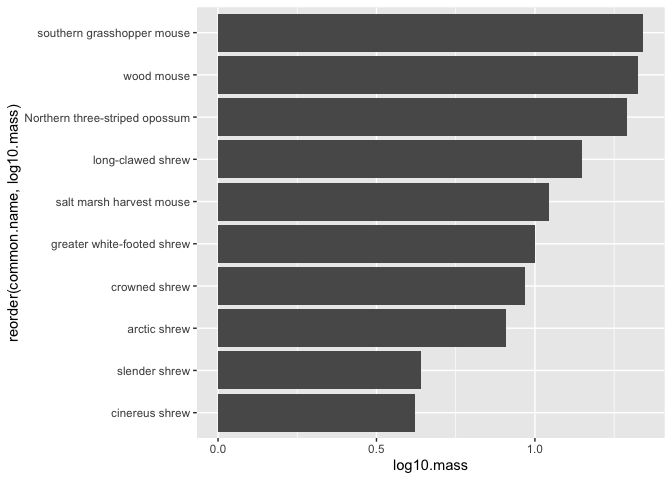

```r
homerange %>%
  filter(class=="mammalia") %>%
  top_n(-10, log10.mass) %>%
  ggplot(aes(x=reorder(common.name, log10.mass), y=log10.mass))+
  geom_col()+
  coord_flip()
```

## That’s it, let’s take a break!

–>[Home](https://jmledford3115.github.io/datascibiol/)